[figure not shown]

# Main Project: Pattern Discovery with Unsupervised Learning

# Credit Card Customer Segmentation

## 1. Exploratory Data Analysis

### 1.1 Problem Definition

AllLife Bank wants to improve its marketing penetration and customer service by understanding the behavior of its existing credit card customers.

The bank plans to use personalized marketing campaigns to acquire new customers and upsell additional products to existing customers. At the same time, the Operations team wants to improve service delivery by understanding how customers interact with the bank through different channels such as branch visits, online visits, and calls.

The objective of this analysis is to explore customer financial characteristics and interaction patterns and identify meaningful relationships among the variables before performing customer segmentation using clustering algorithms.

### Key Business Questions

1. What are the key characteristics and distributions of AllLife Bank's customers?
2. How do customers differ in terms of credit limits and the number of credit cards they possess?
3. How do customers interact with the bank through branch visits, online visits, and calls?
4. Are there meaningful relationships between customers' financial attributes and their interaction behavior?
5. Which variables appear to be most useful for distinguishing different customer segments?
6. What patterns in the data can help the bank design personalized marketing and customer-service strategies?

### 1.2 Import Required Libraries

```python
# Import required libraries

import pandas as pd
import numpy as np
import matplotlib.pyplot as plt
import seaborn as sns

from scipy.cluster.hierarchy import linkage, dendrogram, cophenet
from scipy.spatial.distance import pdist

# Display settings
pd.set_option('display.max_columns', None)
pd.set_option('display.float_format', lambda x: '%.2f' % x)

# Visualization settings
sns.set_theme(style="whitegrid")
```

### 1.3 Load the Dataset

```python
from google.colab import drive

drive.mount('/content/drive')

file_path = '/content/drive/MyDrive/SupervisedLearning/Credit Card Customer Data.xlsx'

df = pd.read_excel(file_path)

df.head()
```

|  | Sl_No | Customer Key | Avg_Credit_Limit | Total_Credit_Cards | Total_visits_bank | Total_visits_online | Total_calls_made |
| --- | --- | --- | --- | --- | --- | --- | --- |
| 0 | 1 | 87073 | 100000 | 2 | 1 | 1 | 0 |
| 1 | 2 | 38414 | 50000 | 3 | 0 | 10 | 9 |
| 2 | 3 | 17341 | 50000 | 7 | 1 | 3 | 4 |
| 3 | 4 | 40496 | 30000 | 5 | 1 | 1 | 4 |
| 4 | 5 | 47437 | 100000 | 6 | 0 | 12 | 3 |

### 1.4 Dataset Dimensions

```python
# Check number of rows and columns

print("Number of rows:", df.shape[0])
print("Number of columns:", df.shape[1])
```

```
Number of rows: 660
Number of columns: 7
```

### Observation

The dataset contains **660 customer records and 7 variables**. Each row represents a customer, while the variables capture customer identification information, credit-related attributes, and interaction behavior with the bank.

### 1.5 First Look at the Dataset

```python
# Display first 10 records

df.head(10)
# Display last 5 records

df.tail()
```

|  | Sl_No | Customer Key | Avg_Credit_Limit | Total_Credit_Cards | Total_visits_bank | Total_visits_online | Total_calls_made |
| --- | --- | --- | --- | --- | --- | --- | --- |
| 655 | 656 | 51108 | 99000 | 10 | 1 | 10 | 0 |
| 656 | 657 | 60732 | 84000 | 10 | 1 | 13 | 2 |
| 657 | 658 | 53834 | 145000 | 8 | 1 | 9 | 1 |
| 658 | 659 | 80655 | 172000 | 10 | 1 | 15 | 0 |
| 659 | 660 | 80150 | 167000 | 9 | 0 | 12 | 2 |

### 1.6 Variable Information and Data Types

```python
# Display column names, data types, and non-null counts

df.info()
# Create a clean summary of variables and data types

data_type_summary = pd.DataFrame({
    'Variable': df.columns,
    'Data Type': df.dtypes.astype(str).values,
    'Non-Null Count': df.notnull().sum().values,
    'Missing Values': df.isnull().sum().values,
    'Unique Values': df.nunique().values
})

data_type_summary
```

```
<class 'pandas.core.frame.DataFrame'>
RangeIndex: 660 entries, 0 to 659
Data columns (total 7 columns):
 #   Column               Non-Null Count  Dtype
---  ------               --------------  -----
 0   Sl_No                660 non-null    int64
 1   Customer Key         660 non-null    int64
 2   Avg_Credit_Limit     660 non-null    int64
 3   Total_Credit_Cards   660 non-null    int64
 4   Total_visits_bank    660 non-null    int64
 5   Total_visits_online  660 non-null    int64
 6   Total_calls_made     660 non-null    int64
dtypes: int64(7)
memory usage: 36.2 KB
```

|  | Variable | Data Type | Non-Null Count | Missing Values | Unique Values |
| --- | --- | --- | --- | --- | --- |
| 0 | Sl_No | int64 | 660 | 0 | 660 |
| 1 | Customer Key | int64 | 660 | 0 | 655 |
| 2 | Avg_Credit_Limit | int64 | 660 | 0 | 110 |
| 3 | Total_Credit_Cards | int64 | 660 | 0 | 10 |
| 4 | Total_visits_bank | int64 | 660 | 0 | 6 |
| 5 | Total_visits_online | int64 | 660 | 0 | 16 |
| 6 | Total_calls_made | int64 | 660 | 0 | 11 |

### Observation

All variables in the dataset are numerical. The dataset does not contain missing values.

`Sl_No` and `Customer Key` are identifier variables and do not represent customer behavior. Therefore, they should not be used as clustering features.

The remaining five variables represent meaningful customer characteristics:

- Average credit limit
- Total credit cards
- Total bank visits
- Total online visits
- Total calls made

These variables will be considered for customer segmentation after appropriate preprocessing.

### 1.7 Statistical Summary

```python
# Create a more informative statistical summary

summary = pd.DataFrame({
    'Count': df.count(),
    'Mean': df.mean(),
    'Median': df.median(),
    'Std Dev': df.std(),
    'Min': df.min(),
    '25%': df.quantile(0.25),
    '50%': df.quantile(0.50),
    '75%': df.quantile(0.75),
    'Max': df.max()
})

summary.round(2)
```

|  | Count | Mean | Median | Std Dev | Min | 25% | 50% | 75% | Max |
| --- | --- | --- | --- | --- | --- | --- | --- | --- | --- |
| Sl_No | 660 | 330.50 | 330.50 | 190.67 | 1 | 165.75 | 330.50 | 495.25 | 660 |
| Customer Key | 660 | 55141.44 | 53874.50 | 25627.77 | 11265 | 33825.25 | 53874.50 | 77202.50 | 99843 |
| Avg_Credit_Limit | 660 | 34574.24 | 18000.00 | 37625.49 | 3000 | 10000.00 | 18000.00 | 48000.00 | 200000 |
| Total_Credit_Cards | 660 | 4.71 | 5.00 | 2.17 | 1 | 3.00 | 5.00 | 6.00 | 10 |
| Total_visits_bank | 660 | 2.40 | 2.00 | 1.63 | 0 | 1.00 | 2.00 | 4.00 | 5 |
| Total_visits_online | 660 | 2.61 | 2.00 | 2.94 | 0 | 1.00 | 2.00 | 4.00 | 15 |
| Total_calls_made | 660 | 3.58 | 3.00 | 2.87 | 0 | 1.00 | 3.00 | 5.00 | 10 |

### Key Statistical Observations

- The average credit limit is approximately **34,574**, while the median is **18,000**, indicating that the distribution is likely positively skewed.
- Customers have an average of approximately **4.71 credit cards**, with the number ranging from 1 to 10.
- Customers make approximately **2.40 bank visits** and **2.61 online visits** on average per year.
- Customers make approximately **3.58 calls** to the bank on average.
- The credit limit has a substantially wider range than the other behavioral variables, making data scaling important before applying distance-based clustering algorithms.

### 1.8 Missing Value Analysis

```python
# Check missing values

missing_values = pd.DataFrame({
    'Missing Count': df.isnull().sum(),
    'Missing Percentage': (df.isnull().sum() / len(df) * 100).round(2)
})

missing_values
```

|  | Missing Count | Missing Percentage |
| --- | --- | --- |
| Sl_No | 0 | 0.00 |
| Customer Key | 0 | 0.00 |
| Avg_Credit_Limit | 0 | 0.00 |
| Total_Credit_Cards | 0 | 0.00 |
| Total_visits_bank | 0 | 0.00 |
| Total_visits_online | 0 | 0.00 |
| Total_calls_made | 0 | 0.00 |

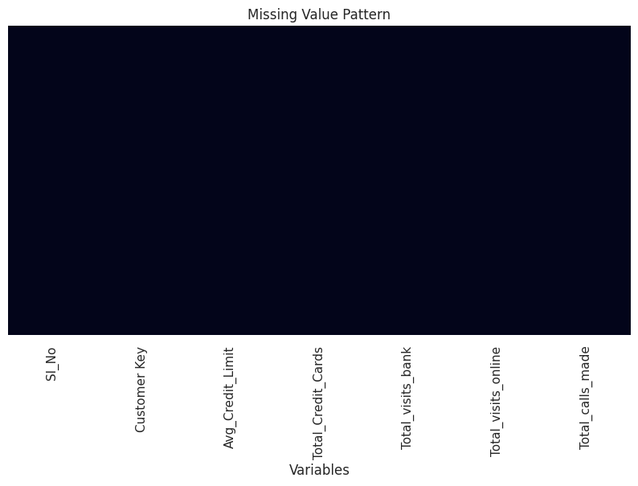

```python
# Visualize missing values

plt.figure(figsize=(10, 5))

sns.heatmap(
    df.isnull(),
    cbar=False,
    yticklabels=False
)

plt.title('Missing Value Pattern')
plt.xlabel('Variables')
plt.show()
```

### Observation

There are **no missing values** in the dataset. Therefore, no imputation or deletion of records is required at this stage.

### 1.9 Duplicate Analysis

```python
# Check duplicate rows

print("Number of duplicate rows:", df.duplicated().sum())
```

```
Number of duplicate rows: 0
```

```python
# Check duplicate Customer Keys

print("Number of duplicated Customer Keys:", df['Customer Key'].duplicated().sum())
```

```
Number of duplicated Customer Keys: 5
```

### Observation

There are no completely duplicated records in the dataset.

A small number of duplicate customer keys are present. Since `Customer Key` is an identifier rather than a clustering feature, these records will be investigated during preprocessing before the final clustering model is built.

### 1.10 Separate Identifier and Analytical Variables

```python
# Identifier variables

id_columns = ['Sl_No', 'Customer Key']

# Variables considered for analysis and clustering
feature_columns = [
    'Avg_Credit_Limit',
    'Total_Credit_Cards',
    'Total_visits_bank',
    'Total_visits_online',
    'Total_calls_made'
]

print("Identifier variables:")
print(id_columns)

print("\nAnalytical variables:")
print(feature_columns)
```

```
Identifier variables:
['Sl_No', 'Customer Key']

Analytical variables:
['Avg_Credit_Limit', 'Total_Credit_Cards', 'Total_visits_bank', 'Total_visits_online', 'Total_calls_made']
```

### Observation

`Sl_No` and `Customer Key` are identifiers and do not describe customer behavior. Including them in clustering could introduce artificial distance between customers and result in misleading segments.

Therefore, the five behavioral and financial variables will be used for further analysis and clustering.

### 1.11 Univariate Analysis

#### 1.11.1 Distribution of Average Credit Limit

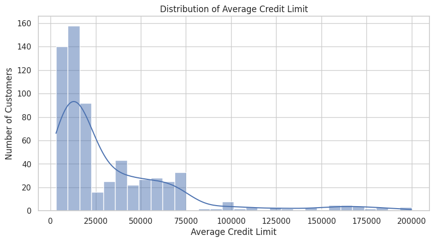

```python
plt.figure(figsize=(10, 5))

sns.histplot(
    df['Avg_Credit_Limit'],
    bins=30,
    kde=True
)

plt.title('Distribution of Average Credit Limit')
plt.xlabel('Average Credit Limit')
plt.ylabel('Number of Customers')
plt.show()
```

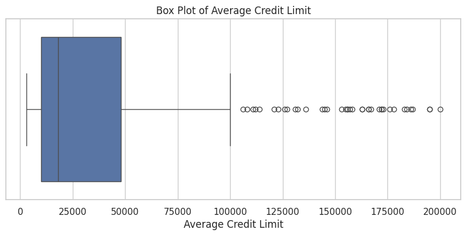

```python
plt.figure(figsize=(10, 4))

sns.boxplot(x=df['Avg_Credit_Limit'])

plt.title('Box Plot of Average Credit Limit')
plt.xlabel('Average Credit Limit')
plt.show()
```

### Observation

The average credit limit is strongly right-skewed. Most customers have relatively moderate credit limits, while a smaller number of customers have substantially higher credit limits.

The box plot also indicates the presence of high-value observations. These observations should not automatically be removed because very high credit limits may represent genuine high-value customers. Their treatment will therefore be evaluated during the data-preprocessing stage.

#### 1.11.2 Total Credit Cards

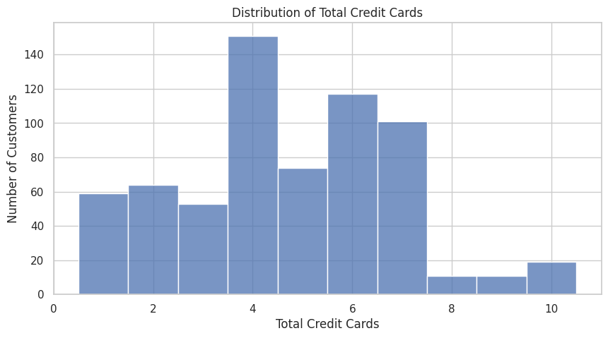

```python
plt.figure(figsize=(10, 5))

sns.histplot(
    df['Total_Credit_Cards'],
    bins=10,
    discrete=True
)

plt.title('Distribution of Total Credit Cards')
plt.xlabel('Total Credit Cards')
plt.ylabel('Number of Customers')
plt.show()
```

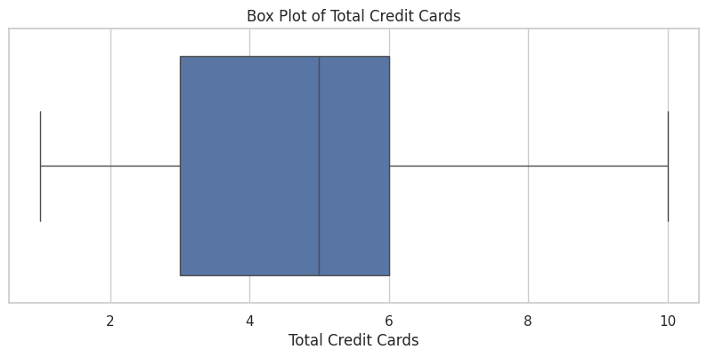

```python
plt.figure(figsize=(10, 4))

sns.boxplot(x=df['Total_Credit_Cards'])

plt.title('Box Plot of Total Credit Cards')
plt.xlabel('Total Credit Cards')
plt.show()
```

### Observation

Customers possess between 1 and 10 credit cards. The distribution is concentrated around the middle range, with an average of approximately 4.7 cards per customer.

The variable has a much smaller numerical range than the average credit limit.

#### 1.11.3 Total Bank Visits

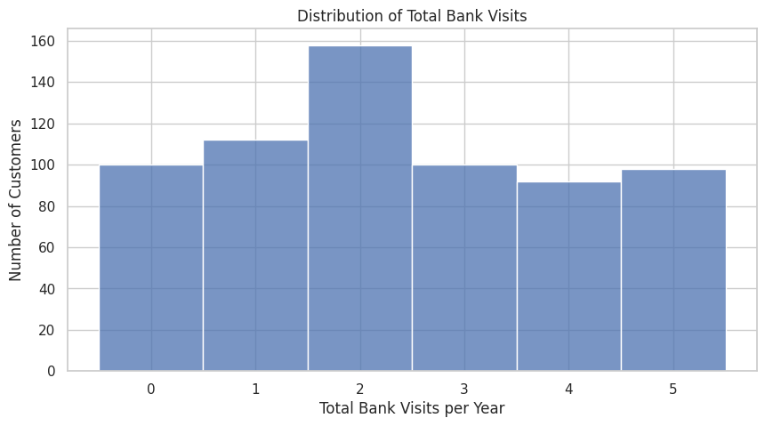

```python
plt.figure(figsize=(10, 5))

sns.histplot(
    df['Total_visits_bank'],
    bins=5,
    discrete=True
)

plt.title('Distribution of Total Bank Visits')
plt.xlabel('Total Bank Visits per Year')
plt.ylabel('Number of Customers')
plt.show()
```

#### 1.11.4 Total Online Visits

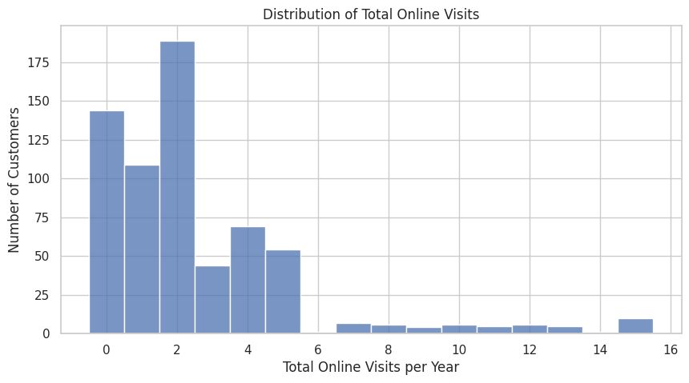

```python
plt.figure(figsize=(10, 5))

sns.histplot(
    df['Total_visits_online'],
    bins=15,
    discrete=True
)

plt.title('Distribution of Total Online Visits')
plt.xlabel('Total Online Visits per Year')
plt.ylabel('Number of Customers')
plt.show()
```

### Observation

Online visits range from 0 to 15 per year. Compared with branch visits, online interactions have a wider range, suggesting differences in customers' digital engagement levels.

#### 1.11.5 Total Calls Made

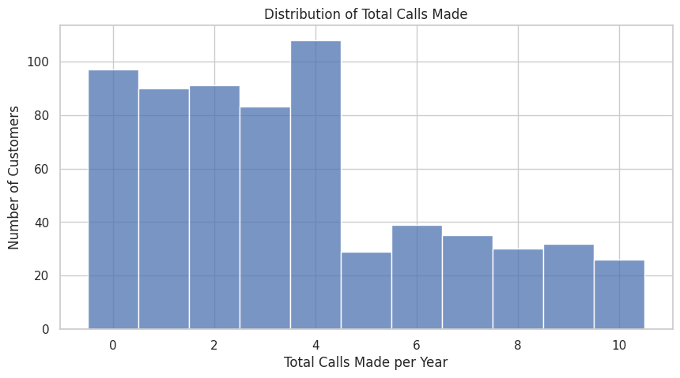

```python
plt.figure(figsize=(10, 5))

sns.histplot(
    df['Total_calls_made'],
    bins=10,
    discrete=True
)

plt.title('Distribution of Total Calls Made')
plt.xlabel('Total Calls Made per Year')
plt.ylabel('Number of Customers')
plt.show()
```

### Observation

The number of calls made by customers ranges from 0 to 10 per year. The distribution indicates varying levels of dependence on the bank's call-center channel.

### 1.12 Combined Box Plots

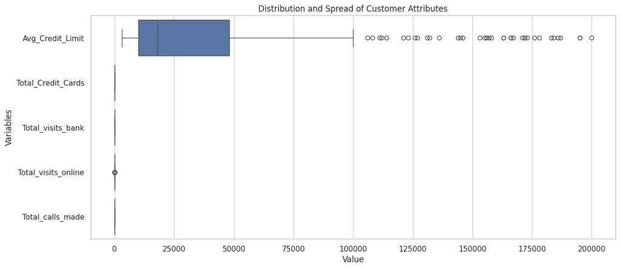

```python
plt.figure(figsize=(14, 6))

sns.boxplot(
    data=df[feature_columns],
    orient='h'
)

plt.title('Distribution and Spread of Customer Attributes')
plt.xlabel('Value')
plt.ylabel('Variables')
plt.show()
```

### Observation

The financial variable, `Avg_Credit_Limit`, has a substantially larger numerical scale and greater variability than the customer interaction variables.

This difference in scale reinforces the need for standardization before distance-based clustering techniques such as K-Means and hierarchical clustering are applied.

### 1.13 Bivariate Analysis

#### 1.13.1 Correlation Heatmap

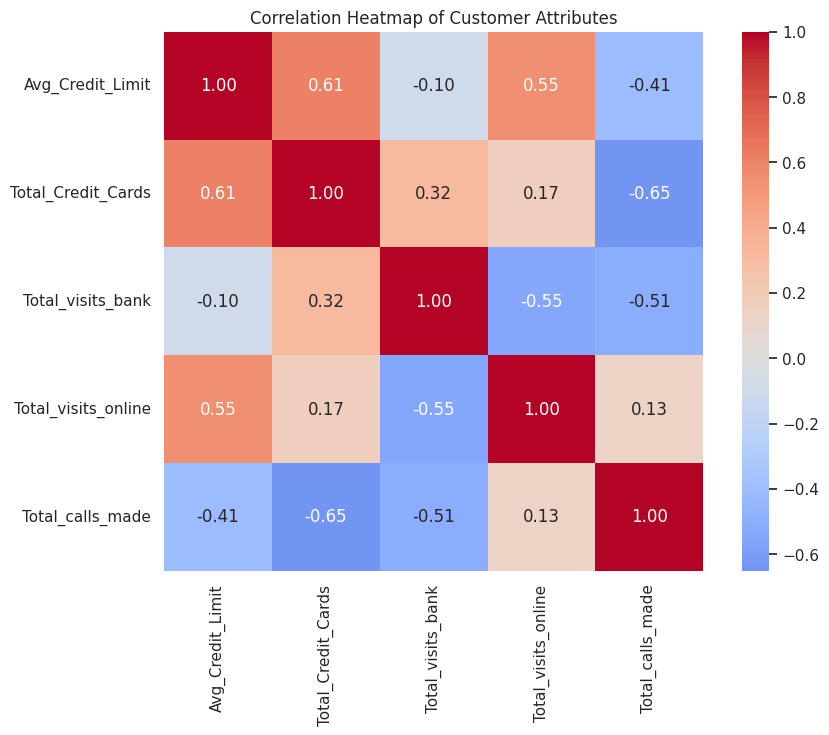

```python
# Correlation matrix for analytical variables

corr_matrix = df[feature_columns].corr()

plt.figure(figsize=(10, 7))

sns.heatmap(
    corr_matrix,
    annot=True,
    fmt='.2f',
    cmap='coolwarm',
    center=0,
    square=True
)

plt.title('Correlation Heatmap of Customer Attributes')
plt.show()
```

### Observation

The correlation analysis indicates meaningful relationships among several customer attributes.

These relationships suggest that customers with different financial profiles may also demonstrate different preferences for interacting with the bank.

#### 1.13.2 Credit Limit vs Credit Cards

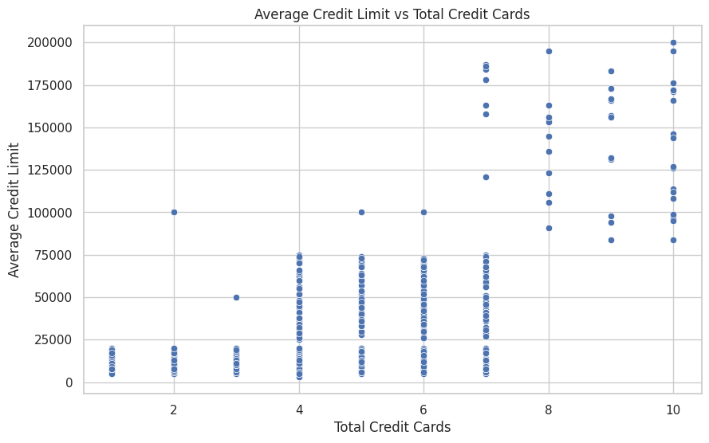

```python
plt.figure(figsize=(10, 6))

sns.scatterplot(
    data=df,
    x='Total_Credit_Cards',
    y='Avg_Credit_Limit'
)

plt.title('Average Credit Limit vs Total Credit Cards')
plt.xlabel('Total Credit Cards')
plt.ylabel('Average Credit Limit')
plt.show()
```

### Observation

There is a positive association between the number of credit cards and average credit limit. Customers with more credit cards tend to have higher credit limits, although the relationship is not perfectly linear.

This suggests that credit-card ownership can be an important variable when distinguishing customers based on their financial profile.

#### 1.13.3 Credit Limit vs Online Visits

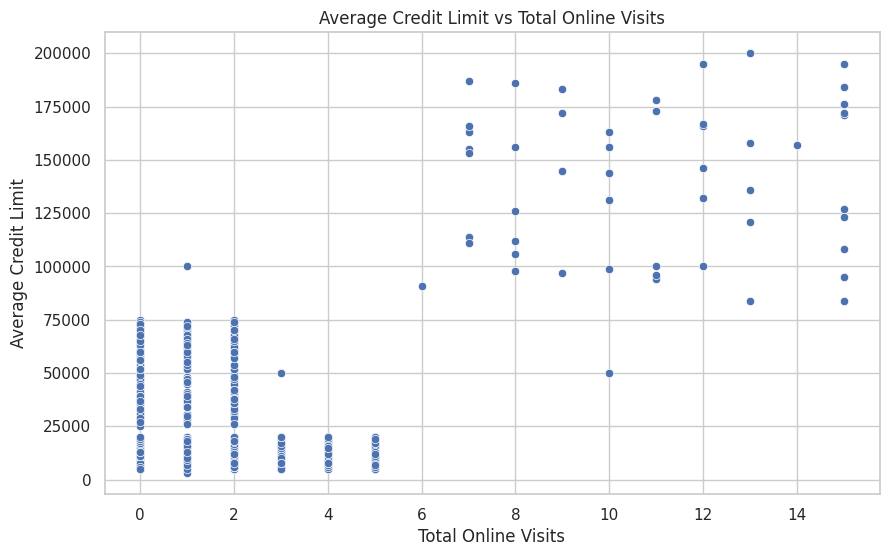

```python
plt.figure(figsize=(10, 6))

sns.scatterplot(
    data=df,
    x='Total_visits_online',
    y='Avg_Credit_Limit'
)

plt.title('Average Credit Limit vs Total Online Visits')
plt.xlabel('Total Online Visits')
plt.ylabel('Average Credit Limit')
plt.show()
```

### Observation

Average credit limit shows a positive association with online visits. Customers with higher credit limits tend to have greater online engagement.

This indicates that digital engagement may be related to the financial value of customers and could be useful when developing customer segments.

#### 1.13.4 Bank Visits vs Online Visits

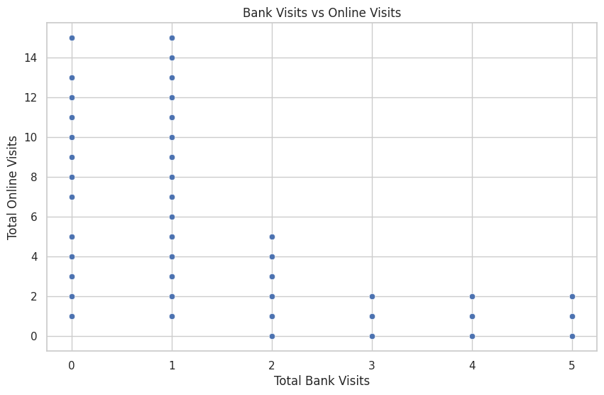

```python
plt.figure(figsize=(10, 6))

sns.scatterplot(
    data=df,
    x='Total_visits_bank',
    y='Total_visits_online'
)

plt.title('Bank Visits vs Online Visits')
plt.xlabel('Total Bank Visits')
plt.ylabel('Total Online Visits')
plt.show()
```

### Observation

Bank visits and online visits show a negative association. Customers who interact more frequently through physical branches tend to have fewer online interactions.

This suggests the presence of different channel preferences among customers, which can be useful for designing differentiated service strategies.

#### 1.13.5 Online Visits vs Calls

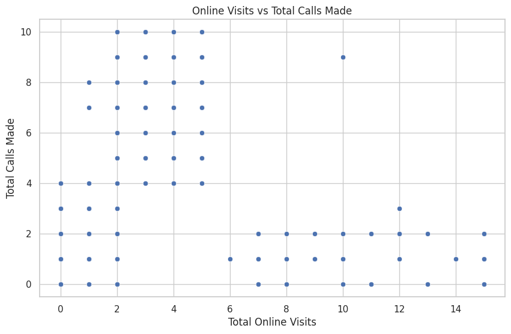

```python
plt.figure(figsize=(10, 6))

sns.scatterplot(
    data=df,
    x='Total_visits_online',
    y='Total_calls_made'
)

plt.title('Online Visits vs Total Calls Made')
plt.xlabel('Total Online Visits')
plt.ylabel('Total Calls Made')
plt.show()
```

### Observation

Online visits and calls made show a relatively weak positive relationship in the overall dataset. This indicates that digital engagement does not necessarily eliminate the need for call-center interactions for every customer.

### 1.13.6 Pairplot

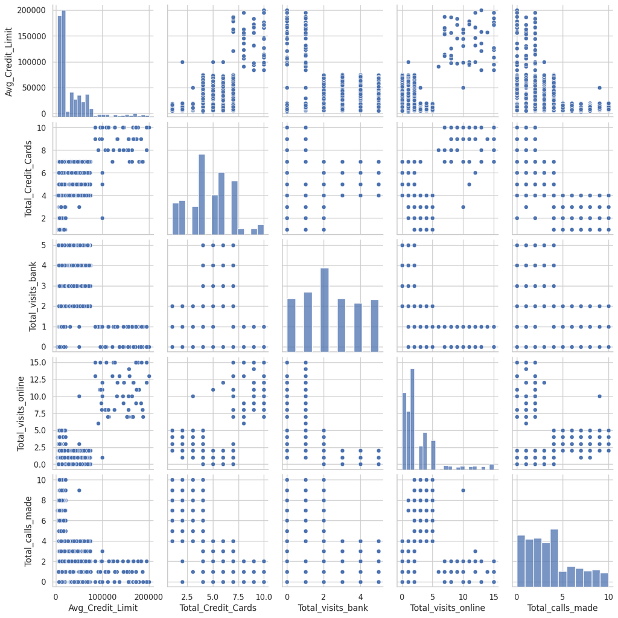

```python
sns.pairplot(
    df[feature_columns],
    diag_kind='hist'
)

plt.show()
```

### Observation

The pairwise relationships provide an overall view of how customers differ across financial and interaction attributes. The plots indicate that the customer population is not completely homogeneous, with visible differences in credit limits and interaction behavior.

These patterns provide preliminary evidence that customer segmentation using clustering algorithms can be useful.

## 1.14 Answers to EDA Questions

### 1. What are the key characteristics of the customers?

The customers differ substantially in their financial profiles and interaction behavior. Average credit limits vary widely, while customers also differ in the number of credit cards they possess and their preference for bank, online, and call-center interactions.

### 2. Which financial variables show meaningful relationships?

Average credit limit has a positive association with the number of credit cards. This suggests that customers with greater credit capacity tend to possess more credit cards.

### 3. How do customers interact with the bank?

Customers use multiple channels including physical bank branches, online services, and call-center support. The variation in interaction frequency indicates differences in channel preferences across customers.

### 4. Are there differences between offline and digital interaction behavior?

Yes. Bank visits and online visits show a negative association, suggesting that customers may exhibit different preferences for physical versus digital banking channels.

### 5. Which variables appear useful for customer segmentation?

The five customer-related variables — average credit limit, total credit cards, total bank visits, total online visits, and total calls made — capture different dimensions of customer behavior and financial profile. Therefore, they are suitable candidates for clustering after preprocessing and scaling.

### 6. Why is scaling important before clustering?

The variables have substantially different numerical ranges, particularly average credit limit compared with the interaction variables. Since K-Means and hierarchical clustering rely on distance calculations, scaling is necessary to prevent variables with larger numerical magnitudes from dominating the clustering process.

### 7. What business opportunity is indicated by the EDA?

The variation in financial value and interaction-channel preferences indicates that AllLife Bank can potentially divide customers into meaningful groups. These groups can then be targeted with personalized marketing campaigns and differentiated customer-service strategies.

## 1.15 Key Insights from EDA

1. **Customer financial profiles vary considerably.**  
   Average credit limits show substantial variability, with a relatively small number of customers having very high credit limits.
2. **Credit-card ownership is associated with customer financial capacity.**  
   Customers with more credit cards tend to have higher average credit limits.
3. **Digital engagement varies significantly across customers.**  
   Online visits range from 0 to 15 per year, indicating different levels of digital interaction with the bank.
4. **Customers demonstrate different channel preferences.**  
   The negative association between bank visits and online visits suggests that some customers may prefer physical banking while others are more digitally oriented.
5. **Call-center dependence differs across customers.**  
   The variation in the number of calls indicates differences in customers' need for assisted service.
6. **The dataset contains potential high-value customer observations.**  
   The high-end observations in average credit limit should be investigated as potential genuine high-value customers rather than automatically removed as errors.
7. **The variables operate on different scales.**  
   Average credit limit has a much larger numerical range than the interaction variables. Therefore, standardization will be required before clustering.
8. **Customer heterogeneity supports the use of clustering.**  
   The observed differences in financial characteristics and interaction behavior suggest that customers may naturally form distinct groups, making clustering an appropriate approach for further analysis.

## 2. Data Preprocessing

Before applying clustering algorithms, the dataset is examined and prepared to ensure that the variables used for clustering are appropriate, comparable in scale, and free from issues that could distort distance-based clustering.

```python
# Create a copy of the original dataset
df_preprocessed = df.copy()

# Display dimensions
print("Dataset dimensions:", df_preprocessed.shape)

# Display first five rows
df_preprocessed.head()
```

```
Dataset dimensions: (660, 7)
```

|  | Sl_No | Customer Key | Avg_Credit_Limit | Total_Credit_Cards | Total_visits_bank | Total_visits_online | Total_calls_made |
| --- | --- | --- | --- | --- | --- | --- | --- |
| 0 | 1 | 87073 | 100000 | 2 | 1 | 1 | 0 |
| 1 | 2 | 38414 | 50000 | 3 | 0 | 10 | 9 |
| 2 | 3 | 17341 | 50000 | 7 | 1 | 3 | 4 |
| 3 | 4 | 40496 | 30000 | 5 | 1 | 1 | 4 |
| 4 | 5 | 47437 | 100000 | 6 | 0 | 12 | 3 |

### 2.1 Identification of Variables

`Sl_No` and `Customer Key` are identifier variables and do not represent customer behavior or financial characteristics. Including identifier variables in a distance-based clustering algorithm could introduce artificial differences between customers.

Therefore, these variables are excluded from the clustering model.

The following five variables represent meaningful financial and customer-interaction characteristics and are retained for clustering:

- Average Credit Limit
- Total Credit Cards
- Total Bank Visits
- Total Online Visits
- Total Calls Made

```python
# Identifier columns
id_columns = ['Sl_No', 'Customer Key']

# Variables selected for clustering
cluster_features = [
    'Avg_Credit_Limit',
    'Total_Credit_Cards',
    'Total_visits_bank',
    'Total_visits_online',
    'Total_calls_made'
]

# Create dataset containing only clustering variables
cluster_data = df_preprocessed[cluster_features].copy()

print("Identifier variables excluded:")
print(id_columns)

print("\nVariables selected for clustering:")
print(cluster_features)

print("\nShape of clustering dataset:", cluster_data.shape)
```

```
Identifier variables excluded:
['Sl_No', 'Customer Key']

Variables selected for clustering:
['Avg_Credit_Limit', 'Total_Credit_Cards', 'Total_visits_bank', 'Total_visits_online', 'Total_calls_made']

Shape of clustering dataset: (660, 5)
```

```python
cluster_data.head()
```

|  | Avg_Credit_Limit | Total_Credit_Cards | Total_visits_bank | Total_visits_online | Total_calls_made |
| --- | --- | --- | --- | --- | --- |
| 0 | 100000 | 2 | 1 | 1 | 0 |
| 1 | 50000 | 3 | 0 | 10 | 9 |
| 2 | 50000 | 7 | 1 | 3 | 4 |
| 3 | 30000 | 5 | 1 | 1 | 4 |
| 4 | 100000 | 6 | 0 | 12 | 3 |

### 2.2 Missing Value Treatment

Missing values are checked across all variables.

Since clustering algorithms require complete observations for calculating distances, missing values would need to be appropriately treated before model development.

The number and percentage of missing values are examined before deciding on any treatment.

```python
# Check missing values
missing_summary = pd.DataFrame({
    'Missing Count': df_preprocessed.isnull().sum(),
    'Missing Percentage': (
        df_preprocessed.isnull().sum() / len(df_preprocessed) * 100
    ).round(2)
})

missing_summary
```

|  | Missing Count | Missing Percentage |
| --- | --- | --- |
| Sl_No | 0 | 0.00 |
| Customer Key | 0 | 0.00 |
| Avg_Credit_Limit | 0 | 0.00 |
| Total_Credit_Cards | 0 | 0.00 |
| Total_visits_bank | 0 | 0.00 |
| Total_visits_online | 0 | 0.00 |
| Total_calls_made | 0 | 0.00 |

```python
# Check missing values specifically in clustering variables

cluster_missing = pd.DataFrame({
    'Missing Count': cluster_data.isnull().sum(),
    'Missing Percentage': (
        cluster_data.isnull().sum() / len(cluster_data) * 100
    ).round(2)
})

cluster_missing
```

|  | Missing Count | Missing Percentage |
| --- | --- | --- |
| Avg_Credit_Limit | 0 | 0.00 |
| Total_Credit_Cards | 0 | 0.00 |
| Total_visits_bank | 0 | 0.00 |
| Total_visits_online | 0 | 0.00 |
| Total_calls_made | 0 | 0.00 |

### Observation

There are no missing values in the dataset, including the variables selected for clustering.

Therefore, no imputation or deletion of observations is required.

This avoids introducing artificial values into the customer financial and interaction variables.

### 2.3 Duplicate Analysis

Duplicate records are checked to determine whether the dataset contains repeated observations.

Both complete row duplicates and duplicated customer identification numbers are examined separately. A repeated `Customer Key` does not necessarily imply that the entire observation is duplicated, so the two cases are treated differently.

```python
# Check completely duplicated rows

duplicate_rows = df_preprocessed.duplicated().sum()

print("Number of completely duplicated rows:", duplicate_rows)
```

```
Number of completely duplicated rows: 0
```

```python
# Check duplicate Customer Keys

duplicate_customer_keys = df_preprocessed['Customer Key'].duplicated().sum()

print("Number of duplicated Customer Key entries:", duplicate_customer_keys)
```

```
Number of duplicated Customer Key entries: 5
```

```python
# Display records with duplicated Customer Keys

duplicated_customers = df_preprocessed[
    df_preprocessed['Customer Key'].duplicated(keep=False)
].sort_values('Customer Key')

duplicated_customers
```

|  | Sl_No | Customer Key | Avg_Credit_Limit | Total_Credit_Cards | Total_visits_bank | Total_visits_online | Total_calls_made |
| --- | --- | --- | --- | --- | --- | --- | --- |
| 48 | 49 | 37252 | 6000 | 4 | 0 | 2 | 8 |
| 432 | 433 | 37252 | 59000 | 6 | 2 | 1 | 2 |
| 332 | 333 | 47437 | 17000 | 7 | 3 | 1 | 0 |
| 4 | 5 | 47437 | 100000 | 6 | 0 | 12 | 3 |
| 411 | 412 | 50706 | 44000 | 4 | 5 | 0 | 2 |
| 541 | 542 | 50706 | 60000 | 7 | 5 | 2 | 2 |
| 391 | 392 | 96929 | 13000 | 4 | 5 | 0 | 0 |
| 398 | 399 | 96929 | 67000 | 6 | 2 | 2 | 2 |
| 104 | 105 | 97935 | 17000 | 2 | 1 | 2 | 10 |
| 632 | 633 | 97935 | 187000 | 7 | 1 | 7 | 0 |

### Observation

There are no completely duplicated rows in the dataset.

However, five `Customer Key` values occur more than once. These records have different financial and interaction attributes, indicating that they are not exact duplicate observations.

Since `Customer Key` is excluded from clustering and the corresponding records contain different customer attributes, the records are retained rather than arbitrarily deleting potentially meaningful observations.

The duplicate customer-key issue is documented as a data-quality observation, while the clustering model uses only the behavioral and financial variables.

### 2.4 Outlier Detection

Outliers are identified using the Interquartile Range (IQR) method.

For each clustering variable, the first quartile (Q1), third quartile (Q3), and IQR are calculated. Observations below Q1 − 1.5 × IQR or above Q3 + 1.5 × IQR are considered potential outliers.

Outlier detection is performed to understand whether extreme observations could disproportionately influence distance-based clustering algorithms.

```python
# Calculate IQR-based outlier statistics

outlier_summary = []

for column in cluster_features:
    Q1 = cluster_data[column].quantile(0.25)
    Q3 = cluster_data[column].quantile(0.75)
    IQR = Q3 - Q1

    lower_bound = Q1 - 1.5 * IQR
    upper_bound = Q3 + 1.5 * IQR

    outliers = cluster_data[
        (cluster_data[column] < lower_bound) |
        (cluster_data[column] > upper_bound)
    ]

    outlier_summary.append({
        'Variable': column,
        'Q1': Q1,
        'Q3': Q3,
        'IQR': IQR,
        'Lower Bound': lower_bound,
        'Upper Bound': upper_bound,
        'Outlier Count': len(outliers),
        'Outlier %': round(len(outliers) / len(cluster_data) * 100, 2)
    })

outlier_summary = pd.DataFrame(outlier_summary)

outlier_summary
```

|  | Variable | Q1 | Q3 | IQR | Lower Bound | Upper Bound | Outlier Count | Outlier % |
| --- | --- | --- | --- | --- | --- | --- | --- | --- |
| 0 | Avg_Credit_Limit | 10000.00 | 48000.00 | 38000.00 | -47000.00 | 105000.00 | 39 | 5.91 |
| 1 | Total_Credit_Cards | 3.00 | 6.00 | 3.00 | -1.50 | 10.50 | 0 | 0.00 |
| 2 | Total_visits_bank | 1.00 | 4.00 | 3.00 | -3.50 | 8.50 | 0 | 0.00 |
| 3 | Total_visits_online | 1.00 | 4.00 | 3.00 | -3.50 | 8.50 | 37 | 5.61 |
| 4 | Total_calls_made | 1.00 | 5.00 | 4.00 | -5.00 | 11.00 | 0 | 0.00 |

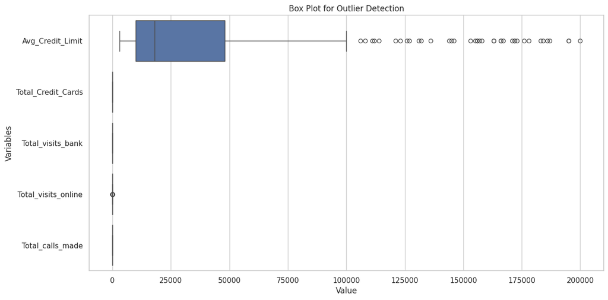

```python
plt.figure(figsize=(14, 7))

sns.boxplot(
    data=cluster_data,
    orient='h'
)

plt.title('Box Plot for Outlier Detection')
plt.xlabel('Value')
plt.ylabel('Variables')

plt.show()
```

### Observation

The box plots indicate potential extreme observations mainly in `Avg_Credit_Limit` and `Total_visits_online`.

The other three variables do not show IQR-based outliers.

The observations identified as outliers are not automatically considered erroneous. In a banking context, an unusually high credit limit or high online activity may represent a genuine customer segment. Therefore, the treatment strategy should reduce the influence of extreme values without unnecessarily removing potentially valuable customers.

### 2.5 Outlier Treatment

The identified outliers are treated using IQR-based capping rather than removing the corresponding customer records.

This approach limits the influence of extreme values on distance calculations while preserving the customer observations in the dataset.

Capping is applied only to the variables with identified IQR-based outliers. The original dataset is retained separately so that business interpretation and cluster profiling can refer to the original customer values where appropriate.

```python
# Create a copy for outlier treatment

cluster_data_capped = cluster_data.copy()

# Apply IQR-based capping
for column in cluster_features:
    Q1 = cluster_data_capped[column].quantile(0.25)
    Q3 = cluster_data_capped[column].quantile(0.75)
    IQR = Q3 - Q1

    lower_bound = Q1 - 1.5 * IQR
    upper_bound = Q3 + 1.5 * IQR

    cluster_data_capped[column] = cluster_data_capped[column].clip(
        lower=lower_bound,
        upper=upper_bound
    )

print("Outlier treatment using IQR capping completed.")
```

```
Outlier treatment using IQR capping completed.
```

#### 2.6.2 Verify Treatment

```python
# Check the maximum and minimum values before and after capping

comparison = pd.DataFrame({
    'Original Min': cluster_data[cluster_features].min(),
    'Capped Min': cluster_data_capped[cluster_features].min(),
    'Original Max': cluster_data[cluster_features].max(),
    'Capped Max': cluster_data_capped[cluster_features].max()
})

comparison
```

|  | Original Min | Capped Min | Original Max | Capped Max |
| --- | --- | --- | --- | --- |
| Avg_Credit_Limit | 3000 | 3000.00 | 200000 | 105000.00 |
| Total_Credit_Cards | 1 | 1.00 | 10 | 10.00 |
| Total_visits_bank | 0 | 0.00 | 5 | 5.00 |
| Total_visits_online | 0 | 0.00 | 15 | 8.50 |
| Total_calls_made | 0 | 0.00 | 10 | 10.00 |

```python
# Verify remaining IQR outliers after capping

remaining_outliers = []

for column in cluster_features:
    Q1 = cluster_data_capped[column].quantile(0.25)
    Q3 = cluster_data_capped[column].quantile(0.75)
    IQR = Q3 - Q1

    lower_bound = Q1 - 1.5 * IQR
    upper_bound = Q3 + 1.5 * IQR

    count = (
        (cluster_data_capped[column] < lower_bound) |
        (cluster_data_capped[column] > upper_bound)
    ).sum()

    remaining_outliers.append({
        'Variable': column,
        'Remaining Outliers': count
    })

pd.DataFrame(remaining_outliers)
```

|  | Variable | Remaining Outliers |
| --- | --- | --- |
| 0 | Avg_Credit_Limit | 0 |
| 1 | Total_Credit_Cards | 0 |
| 2 | Total_visits_bank | 0 |
| 3 | Total_visits_online | 0 |
| 4 | Total_calls_made | 0 |

### Observation

IQR-based capping reduces the influence of extreme observations while retaining all 660 customer records.

This is preferable to deleting observations because extreme financial and interaction values may represent legitimate customer behavior and can be useful for identifying high-value or highly engaged customer segments.

### 2.6 Feature Engineering

Feature engineering was evaluated based on the business objective and the nature of the available variables.

The dataset already contains direct measures of customer financial profile and interaction behavior:

- Average Credit Limit
- Total Credit Cards
- Total Bank Visits
- Total Online Visits
- Total Calls Made

These variables provide complementary information for customer segmentation.

Additional ratios or composite variables were not introduced because they could duplicate information already captured by the existing variables and may complicate cluster interpretation.

Therefore, the original five analytical variables are retained for clustering.

```python
# Final feature set before scaling

final_features = cluster_data_capped[cluster_features].copy()

print("Number of features:", final_features.shape[1])
print("\nFeatures used for clustering:")
print(final_features.columns.tolist())

final_features.head()
```

```
Number of features: 5

Features used for clustering:
['Avg_Credit_Limit', 'Total_Credit_Cards', 'Total_visits_bank', 'Total_visits_online', 'Total_calls_made']
```

|  | Avg_Credit_Limit | Total_Credit_Cards | Total_visits_bank | Total_visits_online | Total_calls_made |
| --- | --- | --- | --- | --- | --- |
| 0 | 100000 | 2 | 1 | 1.00 | 0 |
| 1 | 50000 | 3 | 0 | 8.50 | 9 |
| 2 | 50000 | 7 | 1 | 3.00 | 4 |
| 3 | 30000 | 5 | 1 | 1.00 | 4 |
| 4 | 100000 | 6 | 0 | 8.50 | 3 |

### 2.7 Data Scaling

The clustering variables have substantially different numerical ranges. For example, `Avg_Credit_Limit` is measured in thousands of currency units, while the interaction variables have much smaller ranges.

Both K-Means and hierarchical clustering rely on distance calculations. Without scaling, variables with larger numerical magnitudes could disproportionately influence the resulting clusters.

Therefore, StandardScaler is used to standardize the clustering variables so that they are placed on a comparable scale.

```python
from sklearn.preprocessing import StandardScaler

# Initialize StandardScaler
scaler = StandardScaler()

# Fit and transform the clustering data
scaled_data = scaler.fit_transform(final_features)

# Convert scaled data back to DataFrame
scaled_data = pd.DataFrame(
    scaled_data,
    columns=cluster_features,
    index=final_features.index
)

scaled_data.head()
```

|  | Avg_Credit_Limit | Total_Credit_Cards | Total_visits_bank | Total_visits_online | Total_calls_made |
| --- | --- | --- | --- | --- | --- |
| 0 | 2.40 | -1.25 | -0.86 | -0.62 | -1.25 |
| 1 | 0.64 | -0.79 | -1.47 | 2.71 | 1.89 |
| 2 | 0.64 | 1.06 | -0.86 | 0.27 | 0.15 |
| 3 | -0.06 | 0.14 | -0.86 | -0.62 | 0.15 |
| 4 | 2.40 | 0.60 | -1.47 | 2.71 | -0.20 |

#### 2.8.1 Verify Scaling

```python
# Verify mean and standard deviation after scaling

scaling_check = pd.DataFrame({
    'Mean': scaled_data.mean(),
    'Standard Deviation': scaled_data.std()
})

scaling_check.round(3)
```

|  | Mean | Standard Deviation |
| --- | --- | --- |
| Avg_Credit_Limit | 0.00 | 1.00 |
| Total_Credit_Cards | 0.00 | 1.00 |
| Total_visits_bank | -0.00 | 1.00 |
| Total_visits_online | -0.00 | 1.00 |
| Total_calls_made | -0.00 | 1.00 |

### Observation

After standardization, all clustering variables are on a comparable scale, with means approximately equal to zero and standard deviations approximately equal to one.

This prevents the variables with larger numerical ranges from dominating the distance calculations used by K-Means and hierarchical clustering.

### 2.9 Final Dataset Validation

```python
# Final validation of clustering data

print("Final clustering dataset shape:", scaled_data.shape)

print("\nMissing values:")
print(scaled_data.isnull().sum())

print("\nData types:")
print(scaled_data.dtypes)

print("\nSummary statistics after scaling:")
display(scaled_data.describe().round(2))
```

```
Final clustering dataset shape: (660, 5)

Missing values:
Avg_Credit_Limit       0
Total_Credit_Cards     0
Total_visits_bank      0
Total_visits_online    0
Total_calls_made       0
dtype: int64

Data types:
Avg_Credit_Limit       float64
Total_Credit_Cards     float64
Total_visits_bank      float64
Total_visits_online    float64
Total_calls_made       float64
dtype: object

Summary statistics after scaling:
```

|  | Avg_Credit_Limit | Total_Credit_Cards | Total_visits_bank | Total_visits_online | Total_calls_made |
| --- | --- | --- | --- | --- | --- |
| count | 660.00 | 660.00 | 660.00 | 660.00 | 660.00 |
| mean | 0.00 | 0.00 | -0.00 | -0.00 | -0.00 |
| std | 1.00 | 1.00 | 1.00 | 1.00 | 1.00 |
| min | -1.01 | -1.71 | -1.47 | -1.06 | -1.25 |
| 25% | -0.76 | -0.79 | -0.86 | -0.62 | -0.90 |
| 50% | -0.48 | 0.14 | -0.25 | -0.18 | -0.20 |
| 75% | 0.57 | 0.60 | 0.98 | 0.71 | 0.49 |
| max | 2.57 | 2.44 | 1.59 | 2.71 | 2.24 |

```python
# Final list of variables used for clustering

print("Final variables used for clustering:")
for i, column in enumerate(cluster_features, 1):
    print(f"{i}. {column}")
```

```
Final variables used for clustering:
1. Avg_Credit_Limit
2. Total_Credit_Cards
3. Total_visits_bank
4. Total_visits_online
5. Total_calls_made
```

## 2.8 Preprocessing Summary

The following preprocessing steps were completed before clustering:

| Step | Finding / Treatment | Rationale |
| --- | --- | --- |
| Identifier variables | `Sl_No` and `Customer Key` excluded | They are identifiers and do not represent customer behavior |
| Missing values | No missing values found | No imputation required |
| Duplicate rows | No completely duplicated rows found | No duplicate-row removal required |
| Duplicate Customer Keys | 5 repeated keys identified; records retained | Repeated keys have different attributes and are not exact duplicates |
| Outliers | IQR method used for detection | Identifies extreme observations that may affect distance-based clustering |
| Outlier treatment | IQR-based capping | Reduces influence of extreme values while retaining customer observations |
| Feature engineering | No additional features created | Existing variables adequately represent financial and interaction behavior |
| Scaling | StandardScaler applied | Required because clustering is distance-based and variables have different scales |

The resulting standardized dataset contains 660 customer observations and 5 clustering variables and is ready for K-Means and hierarchical clustering.

## 3. K-Means Clustering

K-Means clustering is used to segment AllLife Bank customers into groups with similar financial characteristics and interaction behavior.

The clustering model is built using the five standardized customer attributes selected during data preprocessing:

- Average Credit Limit
- Total Credit Cards
- Total Bank Visits
- Total Online Visits
- Total Calls Made

Since K-Means is a distance-based algorithm, the standardized dataset prepared during preprocessing is used.

The appropriate number of clusters is determined using both the Elbow Method and Silhouette Score.

```python
# Verify the data prepared for clustering

print("Shape of scaled data:", scaled_data.shape)
print("\nVariables used for K-Means:")
print(scaled_data.columns.tolist())

scaled_data.head()
```

```
Shape of scaled data: (660, 5)

Variables used for K-Means:
['Avg_Credit_Limit', 'Total_Credit_Cards', 'Total_visits_bank', 'Total_visits_online', 'Total_calls_made']
```

|  | Avg_Credit_Limit | Total_Credit_Cards | Total_visits_bank | Total_visits_online | Total_calls_made |
| --- | --- | --- | --- | --- | --- |
| 0 | 2.40 | -1.25 | -0.86 | -0.62 | -1.25 |
| 1 | 0.64 | -0.79 | -1.47 | 2.71 | 1.89 |
| 2 | 0.64 | 1.06 | -0.86 | 0.27 | 0.15 |
| 3 | -0.06 | 0.14 | -0.86 | -0.62 | 0.15 |
| 4 | 2.40 | 0.60 | -1.47 | 2.71 | -0.20 |

### 3.1 Finding the Optimal Number of Clusters

K-Means requires the number of clusters to be specified in advance. Therefore, multiple values of K are evaluated.

The Elbow Method is used to examine the reduction in within-cluster variation as the number of clusters increases. The Silhouette Score is also calculated to evaluate the quality and separation of the resulting clusters.

A range of 2 to 10 clusters is evaluated.

```python
from sklearn.cluster import KMeans
from sklearn.metrics import silhouette_score
import matplotlib.pyplot as plt
import pandas as pd
import numpy as np

# Store results
kmeans_results = []

# Test K values from 2 to 10
for k in range(2, 11):

    kmeans = KMeans(
        n_clusters=k,
        random_state=42,
        n_init=10
    )

    labels = kmeans.fit_predict(scaled_data)

    inertia = kmeans.inertia_
    silhouette = silhouette_score(scaled_data, labels)

    kmeans_results.append({
        'Number of Clusters': k,
        'Inertia': inertia,
        'Silhouette Score': silhouette
    })

kmeans_results_df = pd.DataFrame(kmeans_results)

kmeans_results_df.round(4)
```

|  | Number of Clusters | Inertia | Silhouette Score |
| --- | --- | --- | --- |
| 0 | 2 | 1949.90 | 0.42 |
| 1 | 3 | 998.47 | 0.52 |
| 2 | 4 | 813.87 | 0.38 |
| 3 | 5 | 715.78 | 0.35 |
| 4 | 6 | 640.18 | 0.27 |
| 5 | 7 | 588.73 | 0.27 |
| 6 | 8 | 560.07 | 0.26 |
| 7 | 9 | 539.55 | 0.25 |
| 8 | 10 | 512.20 | 0.24 |

#### Elbow Curve

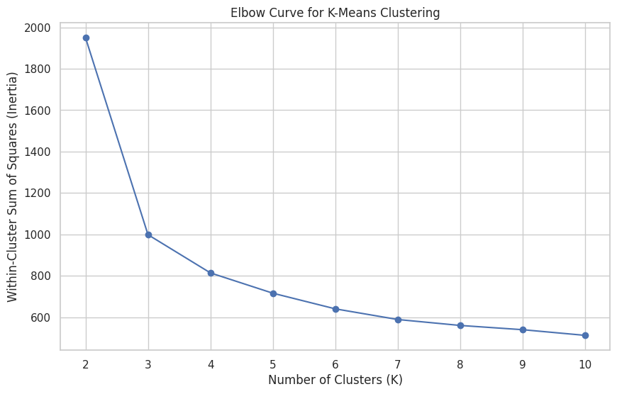

```python
plt.figure(figsize=(10, 6))

plt.plot(
    kmeans_results_df['Number of Clusters'],
    kmeans_results_df['Inertia'],
    marker='o'
)

plt.title('Elbow Curve for K-Means Clustering')
plt.xlabel('Number of Clusters (K)')
plt.ylabel('Within-Cluster Sum of Squares (Inertia)')
plt.xticks(range(2, 11))
plt.show()
```

### Observation — Elbow Method

The inertia decreases substantially as the number of clusters increases from 2 to 3. After K = 3, the reduction in inertia becomes comparatively smaller.

This indicates an elbow around **K = 3**, suggesting that three clusters provide a reasonable balance between within-cluster compactness and model simplicity.

#### Silhouette Score

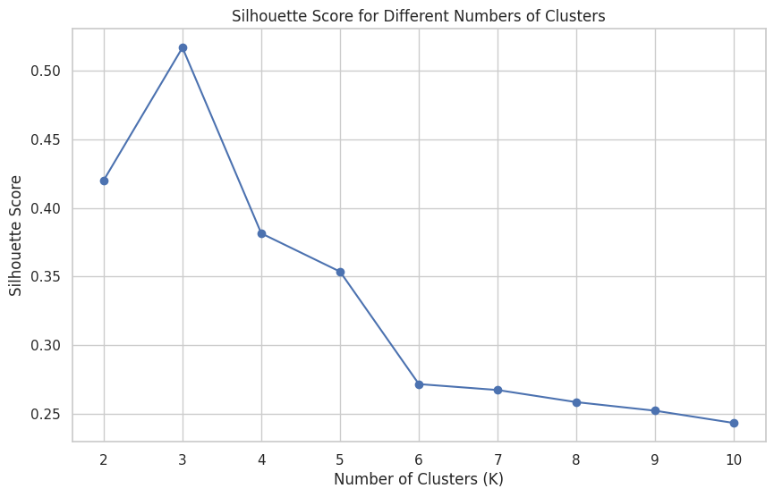

```python
plt.figure(figsize=(10, 6))

plt.plot(
    kmeans_results_df['Number of Clusters'],
    kmeans_results_df['Silhouette Score'],
    marker='o'
)

plt.title('Silhouette Score for Different Numbers of Clusters')
plt.xlabel('Number of Clusters (K)')
plt.ylabel('Silhouette Score')
plt.xticks(range(2, 11))
plt.show()
```

```python
# Display silhouette scores in descending order

silhouette_comparison = kmeans_results_df[
    ['Number of Clusters', 'Silhouette Score']
].sort_values(
    by='Silhouette Score',
    ascending=False
)

silhouette_comparison.round(4)
```

|  | Number of Clusters | Silhouette Score |
| --- | --- | --- |
| 1 | 3 | 0.52 |
| 0 | 2 | 0.42 |
| 2 | 4 | 0.38 |
| 3 | 5 | 0.35 |
| 4 | 6 | 0.27 |
| 5 | 7 | 0.27 |
| 6 | 8 | 0.26 |
| 7 | 9 | 0.25 |
| 8 | 10 | 0.24 |

### Observation — Silhouette Score

The Silhouette Score is highest at **K = 3**, with a score of approximately **0.52**.

The score decreases considerably when the number of clusters is increased beyond three. Therefore, the silhouette analysis strongly supports a three-cluster solution.

### 3.2 Selection of the Optimal Number of Clusters

Both clustering evaluation methods support selecting **three clusters**.

- The Elbow Method shows a noticeable bend around K = 3, after which the improvement in inertia becomes smaller.
- The Silhouette Score reaches its maximum value of approximately **0.52 at K = 3**.
- Increasing the number of clusters beyond three results in lower silhouette scores and therefore does not provide better separation of customers.

Based on the combined evidence from the Elbow Method and Silhouette Score, **K = 3 is selected as the optimal number of clusters for the K-Means model**.

**Optimal K = 3**

The Elbow Method indicates diminishing improvement in within-cluster variation beyond three clusters, while the Silhouette Score is highest at K = 3 (approximately 0.52). Therefore, a three-cluster solution provides the best balance between cluster compactness, separation, and interpretability.

### 3.3 Final K-Means Model

Based on the Elbow Method and Silhouette Score, the final K-Means model is developed using three clusters.

A fixed random state is used to ensure reproducibility of the results.

```python
# Build final K-Means model with 3 clusters

final_kmeans = KMeans(
    n_clusters=3,
    random_state=42,
    n_init=10
)

kmeans_labels = final_kmeans.fit_predict(scaled_data)

# Add cluster labels to the original dataset
df_kmeans = df.copy()

df_kmeans['KMeans_Cluster'] = kmeans_labels

print("Final K-Means model created successfully.")
print("Number of clusters:", df_kmeans['KMeans_Cluster'].nunique())
```

```
Final K-Means model created successfully.
Number of clusters: 3
```

#### Check Cluster Sizes

```python
# Count customers in each cluster

cluster_counts = (
    df_kmeans['KMeans_Cluster']
    .value_counts()
    .sort_index()
)

cluster_counts
```

| KMeans_Cluster | count |
| --- | --- |
| 0 | 386 |
| 1 | 50 |
| 2 | 224 |

**dtype:** int64

```python
# Percentage of customers in each cluster

cluster_distribution = pd.DataFrame({
    'Customer Count': cluster_counts,
    'Percentage': (
        cluster_counts / len(df_kmeans) * 100
    ).round(2)
})

cluster_distribution
```

| KMeans_Cluster | Customer Count | Percentage |
| --- | --- | --- |
| 0 | 386 | 58.48 |
| 1 | 50 | 7.58 |
| 2 | 224 | 33.94 |

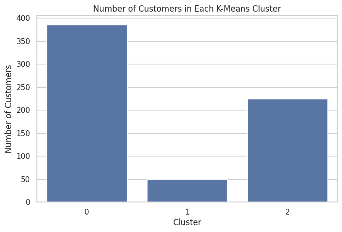

```python
# Visualize cluster sizes

plt.figure(figsize=(8, 5))

sns.barplot(
    x=cluster_distribution.index,
    y=cluster_distribution['Customer Count']
)

plt.title('Number of Customers in Each K-Means Cluster')
plt.xlabel('Cluster')
plt.ylabel('Number of Customers')

plt.show()
```

### Observation

The three clusters are of different sizes.

Cluster 0 contains the largest proportion of customers, followed by Cluster 2. Cluster 1 is substantially smaller and represents a relatively distinct customer group.

The presence of a smaller cluster is not automatically a problem because it may represent a specialized group of high-value customers with characteristics that differ significantly from the majority of customers.

### 3.4 Cluster Profiling

Cluster profiling is performed using the original, unscaled customer variables so that the characteristics of each segment can be interpreted in meaningful business units.

```python
# Calculate mean values for each cluster using original variables

cluster_profile = df_kmeans.groupby('KMeans_Cluster')[cluster_features].mean()

cluster_profile.round(2)
```

| KMeans_Cluster | Avg_Credit_Limit | Total_Credit_Cards | Total_visits_bank | Total_visits_online | Total_calls_made |
| --- | --- | --- | --- | --- | --- |
| 0 | 33782.38 | 5.52 | 3.49 | 0.98 | 2.00 |
| 1 | 141040.00 | 8.74 | 0.60 | 10.90 | 1.08 |
| 2 | 12174.11 | 2.41 | 0.93 | 3.55 | 6.87 |

#### Cluster Profile Visualization

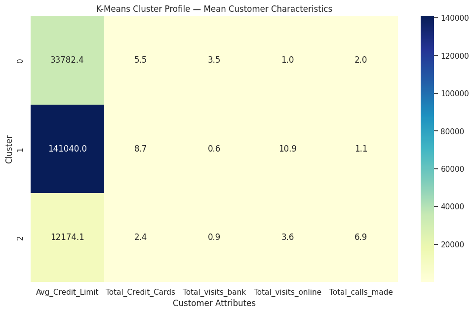

```python
plt.figure(figsize=(12, 7))

sns.heatmap(
    cluster_profile,
    annot=True,
    fmt='.1f',
    cmap='YlGnBu'
)

plt.title('K-Means Cluster Profile — Mean Customer Characteristics')
plt.xlabel('Customer Attributes')
plt.ylabel('Cluster')

plt.show()
```

#### Cluster Profile — Standardized Visualization

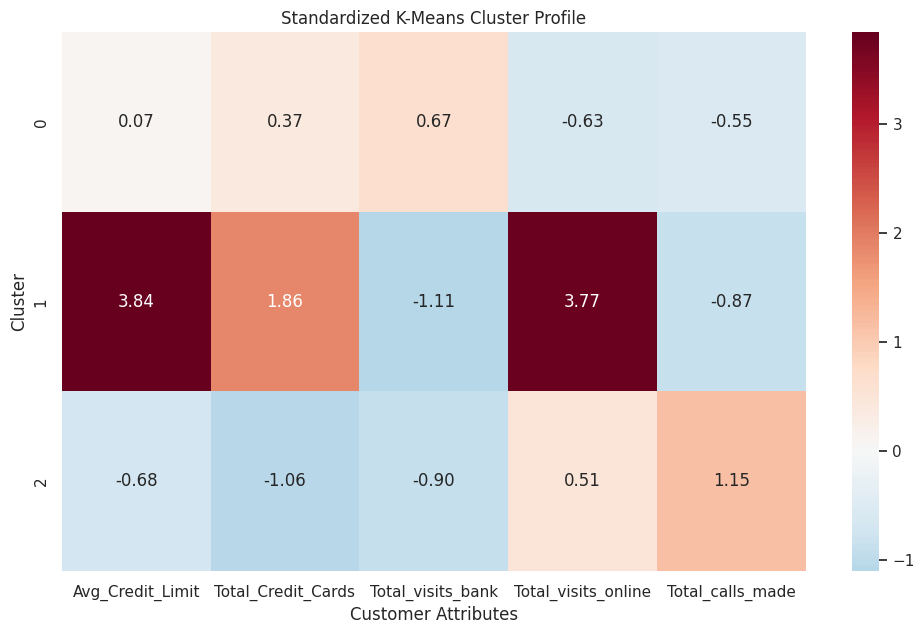

```python
# Calculate standardized cluster means for visualization

cluster_profile_scaled = pd.DataFrame(
    scaler.transform(cluster_profile),
    columns=cluster_features,
    index=cluster_profile.index
)

plt.figure(figsize=(12, 7))

sns.heatmap(
    cluster_profile_scaled,
    annot=True,
    fmt='.2f',
    cmap='RdBu_r',
    center=0
)

plt.title('Standardized K-Means Cluster Profile')
plt.xlabel('Customer Attributes')
plt.ylabel('Cluster')

plt.show()
```

### Observation

The standardized cluster profile highlights the relative characteristics of the three customer segments.

Cluster 1 is substantially above the overall average in credit limit, number of credit cards, and online visits, while being relatively low in branch visits and calls.

Cluster 2 is characterized by lower credit limits and fewer credit cards, combined with relatively high call-center usage.

Cluster 0 represents customers with moderate-to-high credit limits and credit-card ownership, relatively high branch visits, and comparatively low online engagement.

#### Detailed Cluster Statistics

```python
# Detailed cluster statistics

cluster_detailed_profile = df_kmeans.groupby(
    'KMeans_Cluster'
)[cluster_features].agg(
    ['count', 'mean', 'median', 'min', 'max']
)

cluster_detailed_profile.round(2)
```

| KMeans_Cluster | Avg_Credit_Limit count | Avg_Credit_Limit mean | Avg_Credit_Limit median | Avg_Credit_Limit min | Avg_Credit_Limit max | Total_Credit_Cards count | Total_Credit_Cards mean | Total_Credit_Cards median | Total_Credit_Cards min | Total_Credit_Cards max | Total_visits_bank count | Total_visits_bank mean | Total_visits_bank median | Total_visits_bank min | Total_visits_bank max | Total_visits_online count | Total_visits_online mean | Total_visits_online median | Total_visits_online min | Total_visits_online max | Total_calls_made count | Total_calls_made mean | Total_calls_made median | Total_calls_made min | Total_calls_made max |
| --- | --- | --- | --- | --- | --- | --- | --- | --- | --- | --- | --- | --- | --- | --- | --- | --- | --- | --- | --- | --- | --- | --- | --- | --- | --- |
| 0 | 386 | 33782.38 | 31000.00 | 5000 | 100000 | 386 | 5.52 | 6.00 | 2 | 7 | 386 | 3.49 | 3.00 | 1 | 5 | 386 | 0.98 | 1.00 | 0 | 3 | 386 | 2.00 | 2.00 | 0 | 4 |
| 1 | 50 | 141040.00 | 145500.00 | 84000 | 200000 | 50 | 8.74 | 9.00 | 5 | 10 | 50 | 0.60 | 1.00 | 0 | 1 | 50 | 10.90 | 11.00 | 6 | 15 | 50 | 1.08 | 1.00 | 0 | 3 |
| 2 | 224 | 12174.11 | 12000.00 | 3000 | 50000 | 224 | 2.41 | 2.00 | 1 | 4 | 224 | 0.93 | 1.00 | 0 | 2 | 224 | 3.55 | 4.00 | 1 | 10 | 224 | 6.87 | 7.00 | 1 | 10 |

#### Percentage Difference from Overall Mean

```python
# Overall mean
overall_mean = df_kmeans[cluster_features].mean()

# Percentage difference of each cluster from overall mean
cluster_pct_difference = (
    (cluster_profile - overall_mean) /
    overall_mean * 100
)

cluster_pct_difference.round(2)
```

| KMeans_Cluster | Avg_Credit_Limit | Total_Credit_Cards | Total_visits_bank | Total_visits_online | Total_calls_made |
| --- | --- | --- | --- | --- | --- |
| 0 | -2.29 | 17.20 | 45.22 | -62.32 | -44.19 |
| 1 | 307.93 | 85.72 | -75.03 | 318.26 | -69.86 |
| 2 | -64.79 | -48.77 | -61.17 | 36.36 | 91.74 |

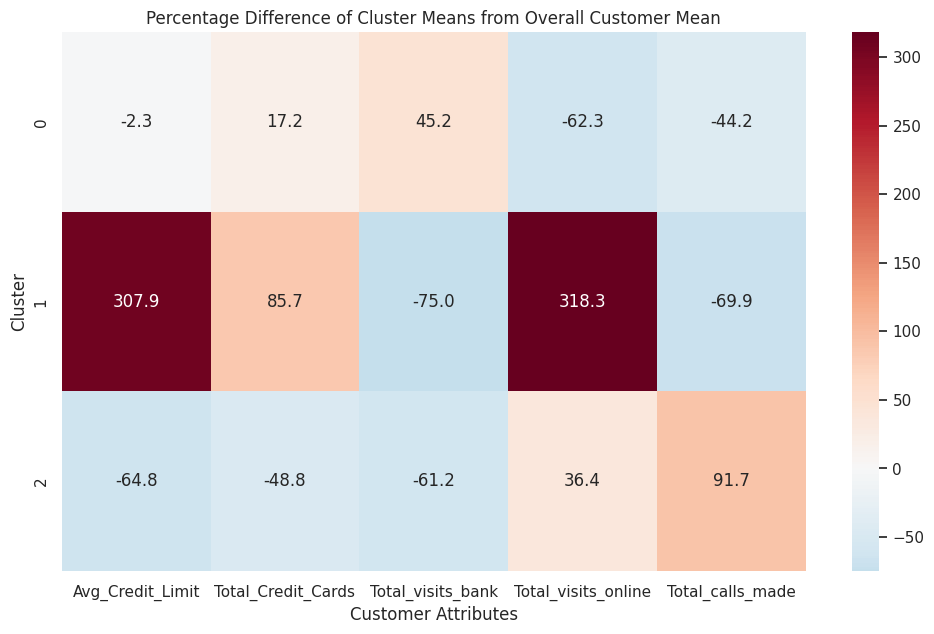

```python
plt.figure(figsize=(12, 7))

sns.heatmap(
    cluster_pct_difference,
    annot=True,
    fmt='.1f',
    center=0,
    cmap='RdBu_r'
)

plt.title('Percentage Difference of Cluster Means from Overall Customer Mean')
plt.xlabel('Customer Attributes')
plt.ylabel('Cluster')

plt.show()
```

## 3.5 K-Means Cluster Characteristics

### Cluster 0 — Moderate-to-High Value, Branch-Oriented Customers

Cluster 0 is the largest segment, containing approximately 386 customers.

These customers have an average credit limit of approximately 33,782 and hold around 5.5 credit cards on average. They make relatively frequent branch visits (approximately 3.5 per year), while their online activity is relatively low at around 1 visit per year. Their call-center usage is also relatively low at approximately 2 calls per year.

This segment appears to have a stronger preference for physical banking channels and represents a sizeable customer base that could benefit from branch-based engagement combined with gradual digital adoption.

### Cluster 1 — High-Value, Digitally Engaged Customers

Cluster 1 contains approximately 50 customers and represents a relatively small but highly valuable segment.

These customers have a very high average credit limit of approximately 141,040 and hold around 8.7 credit cards on average. They also have very high online engagement, with approximately 10.9 online visits per year, while making very few branch visits and calls.

This segment represents high-value and digitally engaged customers who may be strong candidates for premium products, cross-selling, and personalized digital offers.

### Cluster 2 — Lower-Value, High-Service-Contact Customers

Cluster 2 contains approximately 224 customers.

These customers have a relatively low average credit limit of approximately 12,174 and hold around 2.4 credit cards on average. Their branch visits are relatively low, while online visits average around 3.6 per year. The most distinctive characteristic is their high call-center usage, with approximately 6.9 calls per year.

This segment may require greater assisted-service support and represents an opportunity for the bank to improve self-service and digital education while carefully targeting appropriate credit-card and product offers.

#### Business Interpretation Table

| Cluster | Customer Segment | Key Characteristics | Potential Business Focus |
| --- | --- | --- | --- |
| Cluster 0 | Moderate-to-High Value, Branch-Oriented | Moderate-high credit limit, ~5.5 cards, high branch visits, low online usage | Branch engagement, digital adoption, cross-selling |
| Cluster 1 | High-Value, Digitally Engaged | Very high credit limit, ~8.7 cards, very high online usage, low calls/branch visits | Premium products, upselling, personalized digital campaigns |
| Cluster 2 | Lower-Value, High-Service-Contact | Lower credit limit, ~2.4 cards, high call-center usage | Service improvement, self-service adoption, targeted product education |

### 3.6 Visualizing K-Means Clusters in Two Dimensions

Since the clustering is performed using five variables, the resulting clusters cannot be directly visualized in a two-dimensional plot.

PCA is used only as a visualization technique to project the standardized five-dimensional data into two dimensions. The K-Means clustering itself is performed using all five standardized variables.

```python
from sklearn.decomposition import PCA

# PCA only for visualization
pca = PCA(n_components=2, random_state=42)

pca_data = pca.fit_transform(scaled_data)

pca_df = pd.DataFrame(
    pca_data,
    columns=['PC1', 'PC2']
)

pca_df['Cluster'] = kmeans_labels

print(
    "Variance explained by PC1:",
    round(pca.explained_variance_ratio_[0] * 100, 2),
    "%"
)

print(
    "Variance explained by PC2:",
    round(pca.explained_variance_ratio_[1] * 100, 2),
    "%"
)

print(
    "Total variance explained:",
    round(pca.explained_variance_ratio_.sum() * 100, 2),
    "%"
)
```

```
Variance explained by PC1: 47.2 %
Variance explained by PC2: 34.52 %
Total variance explained: 81.72 %
```

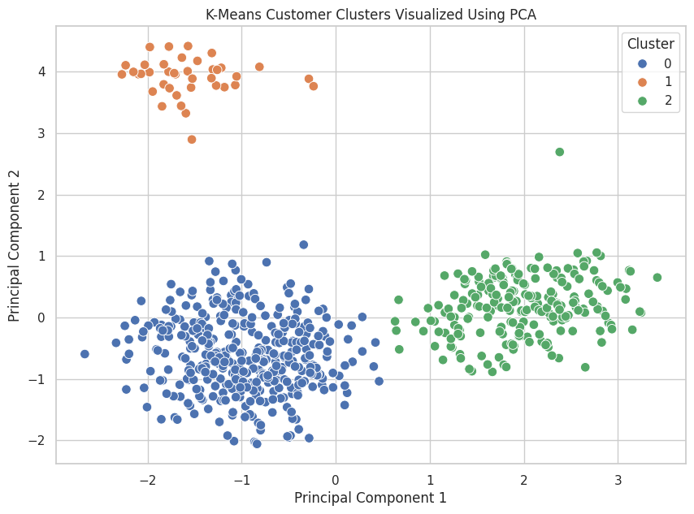

```python
plt.figure(figsize=(10, 7))

sns.scatterplot(
    data=pca_df,
    x='PC1',
    y='PC2',
    hue='Cluster',
    palette='deep',
    s=70
)

plt.title('K-Means Customer Clusters Visualized Using PCA')
plt.xlabel('Principal Component 1')
plt.ylabel('Principal Component 2')
plt.legend(title='Cluster')

plt.show()
```

### Observation

The two-dimensional PCA projection provides a visual representation of the K-Means clusters. The visualization is used only to illustrate the cluster structure; the K-Means algorithm was trained using all five standardized customer attributes.

The degree of separation observed in the visualization provides additional qualitative support for the clustering structure identified through the quantitative evaluation metrics.

## 3.7 K-Means Clustering — Summary

K-Means clustering was applied to the five standardized customer attributes.

The optimal number of clusters was evaluated using both the Elbow Method and Silhouette Score.

The analysis resulted in the selection of **three clusters**:

- The Elbow Method showed a noticeable reduction in inertia up to K = 3, followed by diminishing improvements.
- The Silhouette Score was highest at K = 3, with a value of approximately **0.52**.
- The final three clusters contain 386, 50, and 224 customers respectively.
- Cluster profiling revealed clear differences in financial characteristics and interaction-channel preferences.

The resulting customer segments demonstrate that AllLife Bank's customers are heterogeneous and can be meaningfully differentiated based on their credit profile and interaction behavior.

The three segments provide a foundation for developing personalized marketing campaigns and differentiated customer-service strategies.

## 4. Hierarchical Clustering

Hierarchical clustering is applied as an alternative unsupervised learning technique to identify groups of customers with similar financial characteristics and interaction behavior.

Agglomerative hierarchical clustering is used, where each customer initially forms an individual cluster and similar clusters are progressively merged.

Different linkage methods are evaluated to determine how distances between clusters should be calculated.

The following linkage methods are considered:

- Single Linkage
- Complete Linkage
- Average Linkage
- Ward Linkage

The quality of the resulting hierarchical structures is evaluated using the cophenetic correlation coefficient. Dendrograms are also examined to identify a suitable number of clusters.

### Prepare the Data

```python
# Verify the data used for hierarchical clustering

print("Shape of clustering data:", scaled_data.shape)

print("\nVariables:")
print(scaled_data.columns.tolist())

scaled_data.head()
```

```
Shape of clustering data: (660, 5)

Variables:
['Avg_Credit_Limit', 'Total_Credit_Cards', 'Total_visits_bank', 'Total_visits_online', 'Total_calls_made']
```

|  | Avg_Credit_Limit | Total_Credit_Cards | Total_visits_bank | Total_visits_online | Total_calls_made |
| --- | --- | --- | --- | --- | --- |
| 0 | 2.40 | -1.25 | -0.86 | -0.62 | -1.25 |
| 1 | 0.64 | -0.79 | -1.47 | 2.71 | 1.89 |
| 2 | 0.64 | 1.06 | -0.86 | 0.27 | 0.15 |
| 3 | -0.06 | 0.14 | -0.86 | -0.62 | 0.15 |
| 4 | 2.40 | 0.60 | -1.47 | 2.71 | -0.20 |

### Observation

The hierarchical clustering analysis uses the same five standardized customer attributes used for K-Means:

- Average Credit Limit
- Total Credit Cards
- Total Bank Visits
- Total Online Visits
- Total Calls Made

Using the same standardized input ensures that the two clustering approaches can be compared fairly.

### 4.1 Hierarchical Clustering with Different Linkage Methods

The linkage method determines how the distance between two clusters is calculated.

Four linkage methods are evaluated:

- **Single linkage:** distance between the closest observations in two clusters.
- **Complete linkage:** distance between the farthest observations in two clusters.
- **Average linkage:** average distance between observations in two clusters.
- **Ward linkage:** merges clusters while minimizing the increase in within-cluster variance.

The resulting hierarchical structures are compared using dendrograms and cophenetic correlation.

```python
from scipy.cluster.hierarchy import linkage

# Define linkage methods
linkage_methods = [
    'single',
    'complete',
    'average',
    'ward'
]

# Store linkage matrices
linkage_matrices = {}

for method in linkage_methods:
    linkage_matrices[method] = linkage(
        scaled_data,
        method=method
    )

print("Linkage matrices created for:")
for method in linkage_methods:
    print("-", method)
```

```
Linkage matrices created for:
- single
- complete
- average
- ward
```

### Dendrogram — Single Linkage

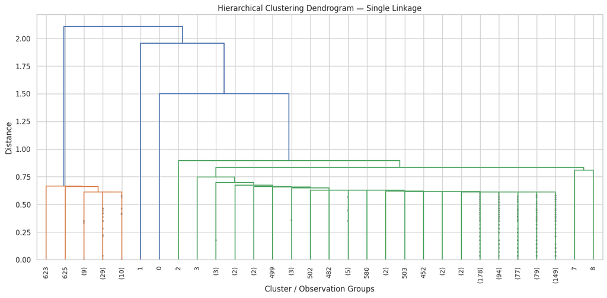

```python
from scipy.cluster.hierarchy import dendrogram
import matplotlib.pyplot as plt

plt.figure(figsize=(16, 7))

dendrogram(
    linkage_matrices['single'],
    truncate_mode='lastp',
    p=30,
    leaf_rotation=90,
    leaf_font_size=10,
    show_contracted=True
)

plt.title('Hierarchical Clustering Dendrogram — Single Linkage')
plt.xlabel('Cluster / Observation Groups')
plt.ylabel('Distance')
plt.show()
```

### Observation — Single Linkage

The single-linkage dendrogram shows how observations are progressively merged based on the minimum distance between clusters.

The dendrogram is also examined for large vertical gaps, which can provide an indication of a suitable number of clusters.

Single linkage can be sensitive to chaining effects, where observations may be linked through a sequence of nearby points.

### Dendrogram — Complete Linkage

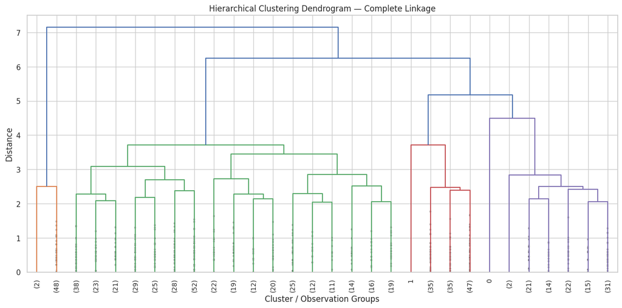

```python
plt.figure(figsize=(16, 7))

dendrogram(
    linkage_matrices['complete'],
    truncate_mode='lastp',
    p=30,
    leaf_rotation=90,
    leaf_font_size=10,
    show_contracted=True
)

plt.title('Hierarchical Clustering Dendrogram — Complete Linkage')
plt.xlabel('Cluster / Observation Groups')
plt.ylabel('Distance')
plt.show()
```

### Observation — Complete Linkage

The complete-linkage dendrogram considers the maximum distance between observations in two clusters.

Compared with single linkage, complete linkage generally produces more compact clusters and can reduce the chaining effect.

The larger vertical distances in the dendrogram are considered when determining a suitable number of clusters.

### Dendrogram — Average Linkage

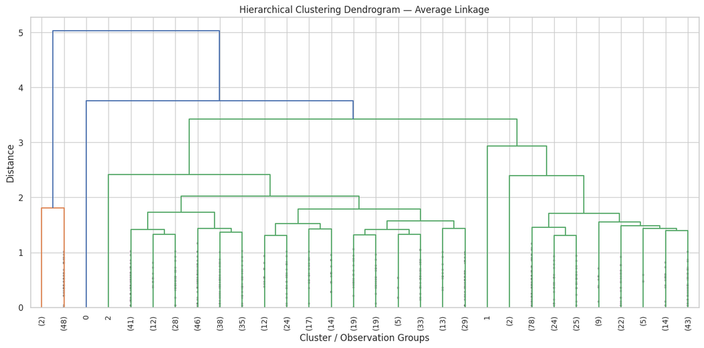

```python
plt.figure(figsize=(16, 7))

dendrogram(
    linkage_matrices['average'],
    truncate_mode='lastp',
    p=30,
    leaf_rotation=90,
    leaf_font_size=10,
    show_contracted=True
)

plt.title('Hierarchical Clustering Dendrogram — Average Linkage')
plt.xlabel('Cluster / Observation Groups')
plt.ylabel('Distance')
plt.show()
```

### Observation — Average Linkage

The average-linkage dendrogram calculates the average distance between observations belonging to two clusters.

It provides a balance between the behavior of single and complete linkage and can produce relatively stable cluster structures.

The dendrogram is examined for distinct separation levels that can help determine the appropriate number of clusters.

### Dendrogram — Ward Linkage

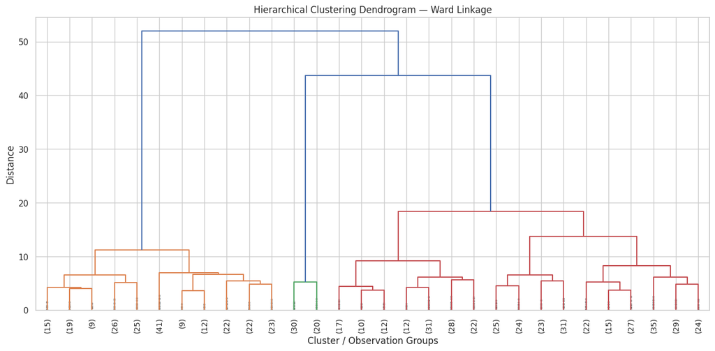

```python
plt.figure(figsize=(16, 7))

dendrogram(
    linkage_matrices['ward'],
    truncate_mode='lastp',
    p=30,
    leaf_rotation=90,
    leaf_font_size=10,
    show_contracted=True
)

plt.title('Hierarchical Clustering Dendrogram — Ward Linkage')
plt.xlabel('Cluster / Observation Groups')
plt.ylabel('Distance')
plt.show()
```

### Observation — Ward Linkage

The Ward-linkage dendrogram merges clusters based on the increase in within-cluster variance.

The dendrogram is examined for large vertical gaps between successive merges. A horizontal cut through an appropriate gap can be used to determine a suitable number of clusters.

Ward linkage is particularly useful when compact, relatively homogeneous clusters are desired.

### Compare the Dendrograms

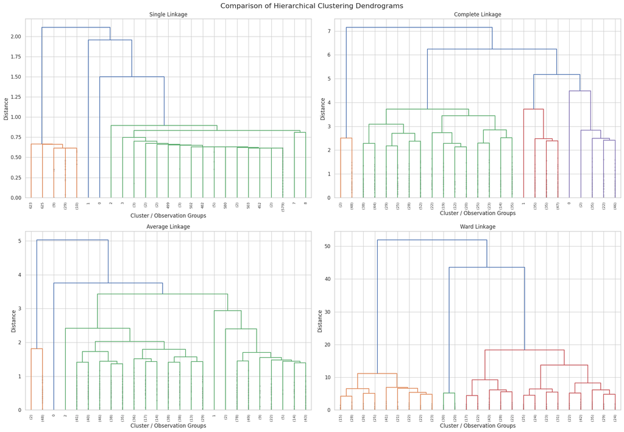

```python
fig, axes = plt.subplots(2, 2, figsize=(20, 14))

for ax, method in zip(axes.flatten(), linkage_methods):

    dendrogram(
        linkage_matrices[method],
        truncate_mode='lastp',
        p=25,
        leaf_rotation=90,
        leaf_font_size=8,
        show_contracted=True,
        ax=ax
    )

    ax.set_title(f'{method.capitalize()} Linkage')
    ax.set_xlabel('Cluster / Observation Groups')
    ax.set_ylabel('Distance')

plt.suptitle(
    'Comparison of Hierarchical Clustering Dendrograms',
    fontsize=16
)

plt.tight_layout()
plt.show()
```

### 4.2 Cophenetic Correlation

The cophenetic correlation coefficient measures how faithfully a hierarchical clustering dendrogram preserves the pairwise distances in the original dataset.

A higher cophenetic correlation indicates that the dendrogram represents the original pairwise distance structure more faithfully.

The cophenetic correlation is calculated for each linkage method and compared to identify the linkage method that provides the most faithful hierarchical representation of the data.

```python
from scipy.cluster.hierarchy import cophenet
from scipy.spatial.distance import pdist

# Calculate original pairwise distances
original_distances = pdist(scaled_data)

# Calculate cophenetic correlations
cophenetic_results = []

for method in linkage_methods:

    coph_corr, coph_distances = cophenet(
        linkage_matrices[method],
        original_distances
    )

    cophenetic_results.append({
        'Linkage Method': method.capitalize(),
        'Cophenetic Correlation': coph_corr
    })

cophenetic_df = pd.DataFrame(cophenetic_results)

cophenetic_df.sort_values(
    by='Cophenetic Correlation',
    ascending=False
).round(4)
```

|  | Linkage Method | Cophenetic Correlation |
| --- | --- | --- |
| 2 | Average | 0.89 |
| 1 | Complete | 0.82 |
| 3 | Ward | 0.77 |
| 0 | Single | 0.67 |

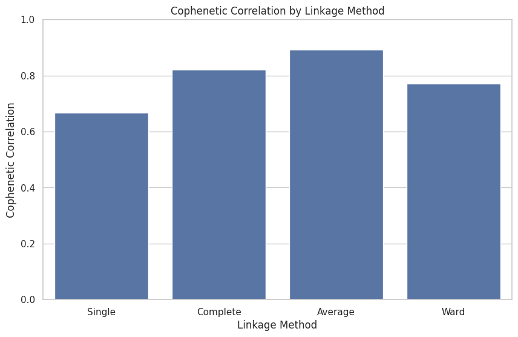

```python
plt.figure(figsize=(10, 6))

sns.barplot(
    data=cophenetic_df,
    x='Linkage Method',
    y='Cophenetic Correlation'
)

plt.title('Cophenetic Correlation by Linkage Method')
plt.xlabel('Linkage Method')
plt.ylabel('Cophenetic Correlation')
plt.ylim(0, 1)

plt.show()
```

### Observation — Cophenetic Correlation

The cophenetic correlation coefficients provide a quantitative comparison of the four linkage methods.

The linkage method with the highest cophenetic correlation provides the most faithful representation of the original pairwise distance structure among the evaluated methods.

Therefore, the linkage method with the highest cophenetic correlation is selected as the preferred linkage method for further hierarchical clustering analysis.

### Select the Best Linkage Method

```python
# Identify the linkage method with the highest cophenetic correlation

best_linkage = (
    cophenetic_df
    .loc[cophenetic_df['Cophenetic Correlation'].idxmax(), 'Linkage Method']
    .lower()
)

best_cophenetic = (
    cophenetic_df
    .loc[cophenetic_df['Cophenetic Correlation'].idxmax(), 'Cophenetic Correlation']
)

print("Best linkage method:", best_linkage.capitalize())
print("Highest cophenetic correlation:", round(best_cophenetic, 4))
```

```
Best linkage method: Average
Highest cophenetic correlation: 0.8927
```

### Selection of Linkage Method

The linkage method with the highest cophenetic correlation is selected for the final hierarchical clustering model.

This selection is based on the ability of the linkage method to preserve the original pairwise distance relationships in the dataset.

### Determine the Number of Clusters

```python
from scipy.cluster.hierarchy import fcluster
from sklearn.metrics import silhouette_score

# Evaluate different numbers of clusters
hierarchical_cluster_results = []

for k in range(2, 11):

    labels = fcluster(
        linkage_matrices[best_linkage],
        t=k,
        criterion='maxclust'
    )

    silhouette = silhouette_score(
        scaled_data,
        labels
    )

    hierarchical_cluster_results.append({
        'Number of Clusters': k,
        'Silhouette Score': silhouette
    })

hierarchical_results_df = pd.DataFrame(
    hierarchical_cluster_results
)

hierarchical_results_df.round(4)
```

|  | Number of Clusters | Silhouette Score |
| --- | --- | --- |
| 0 | 2 | 0.52 |
| 1 | 3 | 0.34 |
| 2 | 4 | 0.48 |
| 3 | 5 | 0.44 |
| 4 | 6 | 0.32 |
| 5 | 7 | 0.27 |
| 6 | 8 | 0.25 |
| 7 | 9 | 0.23 |
| 8 | 10 | 0.23 |

### Hierarchical Silhouette Analysis

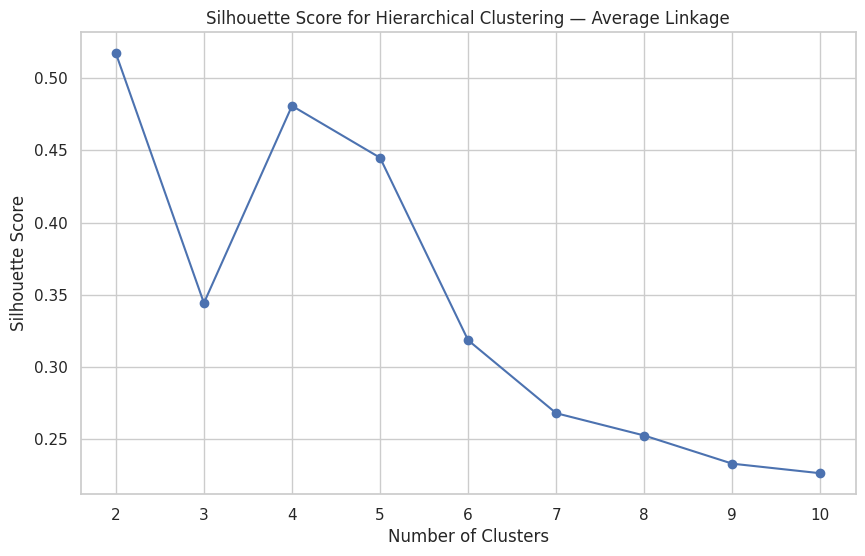

```python
plt.figure(figsize=(10, 6))

plt.plot(
    hierarchical_results_df['Number of Clusters'],
    hierarchical_results_df['Silhouette Score'],
    marker='o'
)

plt.title(
    f'Silhouette Score for Hierarchical Clustering — '
    f'{best_linkage.capitalize()} Linkage'
)

plt.xlabel('Number of Clusters')
plt.ylabel('Silhouette Score')
plt.xticks(range(2, 11))

plt.show()
```

```python
# Identify the K with the highest silhouette score

best_hierarchical_k = (
    hierarchical_results_df
    .loc[
        hierarchical_results_df['Silhouette Score'].idxmax(),
        'Number of Clusters'
    ]
)

best_hierarchical_silhouette = (
    hierarchical_results_df
    .loc[
        hierarchical_results_df['Silhouette Score'].idxmax(),
        'Silhouette Score'
    ]
)

print("Best number of clusters:", best_hierarchical_k)
print(
    "Highest silhouette score:",
    round(best_hierarchical_silhouette, 4)
)
```

```
Best number of clusters: 2
Highest silhouette score: 0.5172
```

### Use the Dendrogram to Validate K

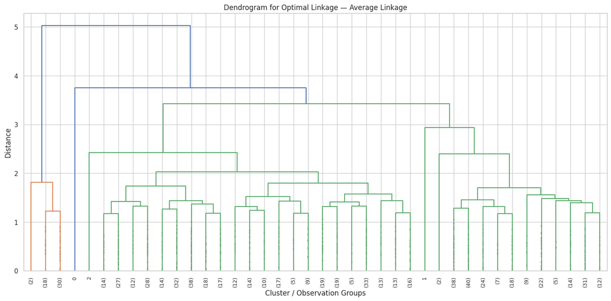

```python
plt.figure(figsize=(18, 8))

dendrogram(
    linkage_matrices[best_linkage],
    truncate_mode='lastp',
    p=40,
    leaf_rotation=90,
    leaf_font_size=9,
    show_contracted=True
)

plt.title(
    f'Dendrogram for Optimal Linkage — '
    f'{best_linkage.capitalize()} Linkage'
)

plt.xlabel('Cluster / Observation Groups')
plt.ylabel('Distance')

plt.show()
```

### Selection of the Number of Clusters

The number of hierarchical clusters is determined using the dendrogram structure together with the silhouette analysis.

The dendrogram is examined for a meaningful vertical separation between groups, while the silhouette scores are compared across candidate cluster counts.

The selected number of clusters should provide a good balance between cluster separation, compactness, and business interpretability.

### Final Hierarchical Model

```python
# Generate final hierarchical cluster labels

hierarchical_labels = fcluster(
    linkage_matrices[best_linkage],
    t=best_hierarchical_k,
    criterion='maxclust'
)

# Create final dataframe
df_hierarchical = df.copy()

df_hierarchical['Hierarchical_Cluster'] = hierarchical_labels

print("Final hierarchical clustering completed.")
print("Linkage method:", best_linkage.capitalize())
print("Number of clusters:", best_hierarchical_k)
```

```
Final hierarchical clustering completed.
Linkage method: Average
Number of clusters: 2
```